# Multilayer Perceptron

Autor: Alberto González Almuiña

Octubre 2019

# 1 **Teoría**

En esta librería se implementa un perceptrón multicapa cuya arquitectura interior es definida por el usuario. Un perceptrón es un algoritmo cuya estructura está conformada por una capa de entrada (a través de la que se inyectan los datos inicialmente), varias capas ocultas y una capa de salida (que es la capa a través de la que se obtiene el resultado). Una arquitectura típica podría ser la siguiente:

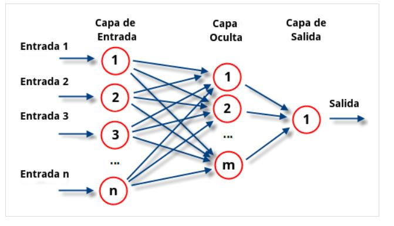

Cada una de estas capas está compuesta por neuronas, que son las unidades mínimas de procesamiento que intervienen en el algoritmo. Las neuronas de la capa de entrada no realizan ningún tipo de procesamiento, sólo insertan los datos a la red. Las neuronas de la capa de salida se corresponden con la salida de toda la red, mientras que en las capas ocultas es dónde se produce el procesamiento de los datos.

Podemos obtener la salida de cada neurona a partir de la siguiente ecuación:
$$f(X) = g(W \cdot X + \vec{b})$$

donde

- W: matriz de pesos
- X: matriz con los datos de entrada
- b: vector de bias
- g: función de activación

El objetivo de la función de activación es introducir no linearidad en el modelo para que pueda adaptarse a este tipo de situaciones (la combinación de ecuaciones lineales supondría una salida siempre lineal) así como reescalar los valores de salida en valores interpretables en función de nuestra variable/s objetivo. Algunas de las funciones de activación más comunes son las siguientes:

- Sigmoide:
  $$f(x) = \frac{1}{1 + e^{-x}}$$
- Tangente hiperbólica:
  $$f(x) = \frac{e^{x} - e^{-x}}{e^{x} + e^{-x}}$$
- ReLu:
  $$f(x) = x^{+} = max(0, x)$$
- Softplus:
  $$f(x) = log(1 + e^{x})$$

En primer lugar, se inicializan los pesos y bias de forma aleatoria y se propagan desde la capa de entrada hasta la capa de salida, donde la salida de las neuronas de la capa anterior se corresponden con las entradas de las neuronas de la siguiente capa. A este método se le conoce como forward propagation. Una vez obtenemos nuestra primera salida, tenemos que compararla con la salida real de nuestro dataset de entrenamiento para poder medir el error que se ha cometido. En este caso utilizaremos el error cuadrático medio (aunque existen otros disponibles):

$$C = \frac{1}{n} \cdot \sum_{i=1}^{n} (\hat{Y_{i}} - Y_{i})^{2}$$

El objetivo es minimizar este error y para ello debemos entrenar a la red. Para ello, utilizaremos la combinación de los algoritmos de back propagation y el descenso del gradiente. El descenso del gradiente busca el mínimo de la función error respecto a los parámetros (en este caso los pesos y bias) mientras que el back propagation va calculando este descenso del gradiente desde la capa de salida hacia las capas anteriores actualizando los pesos y bias. El proceso a seguir sería el siguiente:

1. Calculamos el error de la última capa:
   $$\delta^{L} = \frac{\partial{C}}{\partial{a^{L}}} \cdot \frac{\partial{a^{L}}}{\partial{z^{L}}}$$
2. Retropropagamos el error a la capa anterior:
   $$\delta^{L-1} = W^{L} \delta^{L} \cdot \frac{\partial{a^{L-1}}}{\partial{z^{L-1}}}$$
3. Calculamos las derivadas de la capa usando el error:
   $$\frac{\partial{C}}{\partial{b^{L-1}}} = \delta^{L-1}$$
   $$\frac{\partial{C}}{\partial{W^{L-1}}} = \delta^{L-1} \cdot a^{L-2}$$
4. Actualizamos los pesos y bias:
   $$W = W - \alpha \cdot \frac{\partial{C}}{\partial{W}}$$
   $$b = b - \alpha \cdot \frac{\partial{C}}{\partial{b}}$$

Repetimos este procedimiento un número de iteraciones o bien frenamos el algoritmo cuando el error es menor a un determinado valor umbral (independientemente de en qué iteracion nos encontremos).

# 2 **Definición de la clase ‘Layer’**

Para implementar el perceptrón multicapa se ha creado la clase ‘Layer’:

```r
setClass("Layer",
         slots =  c(

           weights = "matrix",
           threshold = "matrix",
           out = "list",
           delta = "matrix",
           active_function = "list"
         ))
```

cuyos valores se inicializan de la siguiente forma (las neuronas de cada capa pueden tener una función de activación distinta, a elegir entre una de las cuatro que se presentaron en la teoría. También se inicializa de forma distinta las neuronas de la capa de entrada, puesto que sólo inyectan la información pero no procesan):

```r
setMethod("initialize", signature("Layer"), function(.Object, n_con, n_neur, train, target, input_neuron = FALSE, active_function){


  #Definimos las posibles funciones de activación de las neuronas:

  sigmoid_fun<-list(sigmoid = function(x){return(1/(1+exp(-x)))},
                    sigmoid_deriv=function(x){x*(1-x)})

  tanh_fun<-list(tanh = function(x){return(tanh(x))},
                 tanh_deriv = function(x){1-(tanh(x)^2)})

  relu_fun<-list(relu = function(x){if_else(x<0, 0, 1)},
                 relu_deriv = function(x){if_else(x>0, 1, if_else(x==0, 0.5, 0))})

  softplus_fun <- list(sotfplus = function(x){log(1+exp(x))},
                       softplus_deriv = function(x){1/(1+exp(-x))})

  active_function <- switch(active_function,
                       sigmoid_fun = sigmoid_fun,
                       tanh_fun = tanh_fun,
                       relu_fun = relu_fun,
                       softplus_fun = softplus_fun)

  .Object@active_function = active_function

  .Object@weights<-rand(n_con, n_neur)

  f<-compose(partial(matrix, nrow = n_neur),
             partial(rep, times = dim(train[,-target])[1]),
             partial(rand, n_neur, 1))

  .Object@threshold<-f()

  if(input_neuron == T){

    .Object@out <- list(as.matrix(train[,-target]),as.matrix(train[,-target]))
  }

  return(.Object)
})
```

# 3 **Función multilayer_perceptron()**

Esta función permite diseñar un perceptrón multicapa con una arquitectura elegida por el usuario. La función entrena a la red creada a partir de un dataset de entrenamiento y permite predecir los valores de salida de una o varias variables categóricas (tanto binarias como multiclase). Los argumentos de la función son los siguientes:

```
## function (train, test = NULL, target, topology, active_function,
##     lr = 0.1, max_iter = 1000, cost_function = "cost_fun", multiclass = FALSE,
##     predict = FALSE)
## NULL
```

donde:

- train: Dataset de entrenamiento.
- test: Dataset de prueba (si se deja a NULL, la función simplemente entrenará a la red, pero no hará predicciones). Si se cubre, el parámetro ‘predict’ debe ser TRUE.
- target: Valor numérico que representa la/s columna/s a predecir.
- topology: Vector numérico con la topología de la red en el que se indica el número de neuronas por cada capa. Por ejemplo, para una red con 2 neuronas de entrada, 2 capas intermedias de 4 neuronas cada una y una única salida, el parámetro sería c(2, 4, 4, 1).
- active_function: Vector de tipo character de igual longitud al número de capas de la red. Cada valor del vector corresponde con la función de activación empleada en cada capa, pudiendo escogerse uno de los siguientes: ‘sigmoid_fun’, ‘tanh_fun’, ‘relu_fun’ y ‘softplus_fun’.
- lr: Learning Rate para el algoritmo de descenso del gradiente. Por defecto, 0.1.
- max_iter: Número de iteraciones para el algoritmo de descenso del gradiente. Por defecto, 1000.
- cost_function: Función de error para entrenar al algoritmo. Sólo disponible ‘cost_fun’ que representa el error cuadrático medio.
- multiclass: Parámetro booleano que indica si las variables a predecir son binarias o multiclase.
- predict: Parámetro booleano. Si es TRUE, test debe estar cubierto y predice los valores de las variable objetivo.

## 3.1 **Lógica de la función**

La función multilayer_perceptron va llamando a las siguientes funciones de manera secuencial:

- **perceptron_comprobations:** Función que comprueba que los parámetros de entrada son válidos para el correcto funcionamiento de la función. Si no lo son, se interrumpe la ejecución del algoritmo y se muestra un error indicando el motivo del fallo.
- **create_perceptron:** Función que crea la red como un cojunto de capas de clase ‘Layer’ y las almacena en una lista.

```r
  create_perceptron <- function(topology, train, target, active_function){

    neural_net<-map(seq(length(topology)), function(i){

      if(i == 1){

        new("Layer", n_con = 1, n_neur = 1,
            train = train,
            target = target,
            input_neuron = TRUE,
            active_function = active_function[i])


      } else{

          new("Layer",
              n_con = topology[i-1],
              n_neur = topology[i],
              train = train,
              target = target,
              input_neuron = FALSE,
              active_function = active_function[i])

      }

    })

    names(neural_net)<-map_chr(seq(length(topology)), function(i){

      paste("Layer_", i, sep = "")

    })

    return(neural_net)

  }
```

- **forward_propagation:** Función que propaga las salidas de las capas hacia adelante.

```r
  forward_propagation <- function(neural_net){


    for (layer in seq_along(neural_net)[-1]) {

      z<-as.matrix(neural_net[[layer-1]]@out[[2]]) %*% neural_net[[layer]]@weights + t(neural_net[[layer]]@threshold)

      neural_net[[layer]]@out <- list(z, neural_net[[layer]]@active_function[[1]](z))

    }

    return(neural_net)

  }
```

- **back propagation:** Función que calcula las deltas de cada capa para actualizar los pesos y bias en el algoritmo descenso del gradiente.

```r
  back_propagation<-function(neural_net, x_test, cost_function){

    x_test<-as.matrix(x_test)

    for (i in order(seq(length(neural_net)), decreasing = T)) {

      if(i == length(neural_net)){

        neural_net[[i]]@delta <- (cost_fun[[2]](neural_net[[i]]@out[[2]], x_test) * neural_net[[i]]@active_function[[2]](neural_net[[i]]@out[[2]]))

      } else {

        neural_net[[i]]@delta <- (neural_net[[i+1]]@delta %*% t(neural_net[[i+1]]@weights)) * neural_net[[i]]@active_function[[2]](neural_net[[i]]@out[[2]])

      }

    }

    return(neural_net)


  }
```

- **gradient_descent_perceptron:** Función que actualiza los pesos y bias en cada iteración.

```r
  gradient_descent_perceptron<-function(neural_net, x_test, lr, max_iter, threshold = NULL){

    i<-1

    while(i < max_iter){

      for (j in c(2:length(neural_net))) {

        neural_net[[j]]@threshold <- neural_net[[j]]@threshold - (lr * t(neural_net[[j]]@delta))

        neural_net[[j]]@weights <- neural_net[[j]]@weights - lr * mean(neural_net[[j]]@delta)*mean(neural_net[[j-1]]@out[[2]])

      }

      neural_net<-forward_propagation(neural_net = neural_net) %>%
        back_propagation(., x_test, cost_function = cost_function)

      i<-i+1

    }



    return(neural_net)

  }
```

- **perceptron_update:** Se actualizan las dimensiones de la red para adaptarla a los datos del dataset test para poder predecir.

```r
  perceptron_update<-function(neural_net, test, target){

    for (i in seq(length(neural_net))) {

      if(dim(neural_net[[i]]@threshold)[1] == 1){

        slot(neural_net[[i]], "threshold") <- slot(neural_net[[i]], "threshold")[,seq(test[,target])] %>% t() %>% as.matrix()

      } else {

        slot(neural_net[[i]], "threshold") <- slot(neural_net[[i]], "threshold")[,seq(test[,target])]

      }

      if(i == 1){

        slot(neural_net[[i]], "out") <- list(as.matrix(test[, -target]), as.matrix(test[, -target]))

      }

    }

    return(neural_net)

  }
```

- **perceptron:** Función compuesta por las funciones anteriores para realizar una única llamada.

```r
  perceptron<-compose(forward_propagation,
                      partial(gradient_descent_perceptron, x_test = train[, target], lr = lr, max_iter = max_iter),
                      partial(back_propagation, x_test = train[, target],cost_function = cost_function),
                      forward_propagation,
                      partial(create_perceptron, topology = topology, train = train, target = target, active_function = active_function)
  )
```

- Finalmente, en función de los parámetros ‘multiclass’ y ‘predict’, se realiza una serie de lógica que permite obtener las matrices de confusión de los resultados así como otros datos de interés.

# 4 **Ejemplo: Predicción Aprobado Alumnos**

Vamos a trabajar con un dataset de 25600 filas y tres variables. Las dos primeras variables representan dos notas de los alumnos, mientras que la tercera es una variable categórica en la que se indica si el alumno aprueba o no la asignatura. Vamos a intentar predecir esta última variable a partir de las notas de los alumnos. Para ello, entrenaremos a nuestra red con 20 mil registros e intentaremos predecir los 5600 restantes.

En primer lugar, se escalan las dos primeras variables entre 0 y 1 para poder introducirlas en nuestra red. Veamos la estructura de nuestro dataset:

```r
str(notas_alumnos)
```

```
## 'data.frame':    25600 obs. of  3 variables:
##  $ score-1: num  0.06543 0.00327 0.08297 0.43176 0.70194 ...
##  $ score-2: num  0.695 0.195 0.62 0.816 0.655 ...
##  $ label  : int  0 0 0 1 1 0 1 1 1 1 ...
```

Finalmente, llamaremos a la función multilayer_perceptron() creando una red con una topología de 2 neuronas de entrada (una para cada variable de entrada), 2 capas intermedias con 4 neuronas cada una y 1 neurona de salida que nos dará la predicción buscada:

```r
notas<-multilayer_perceptron(train = notas_alumnos[1:20000,],
                             test = notas_alumnos[20001:25600,],
                             target = 3,
                             topology = c(2, 4, 4, 1),
                             active_function = rep('sigmoid_fun', 4),
                             lr = 0.1,
                             max_iter = 1000,
                             predict = TRUE);

notas$conf_matrix
```

```
## Confusion Matrix and Statistics
##
##           Reference
## Prediction    0    1
##          0 2240    0
##          1    0 3360
##
##                Accuracy : 1
##                  95% CI : (0.9993, 1)
##     No Information Rate : 0.6
##     P-Value [Acc > NIR] : < 2.2e-16
##
##                   Kappa : 1
##
##  Mcnemar's Test P-Value : NA
##
##             Sensitivity : 1.0
##             Specificity : 1.0
##          Pos Pred Value : 1.0
##          Neg Pred Value : 1.0
##              Prevalence : 0.4
##          Detection Rate : 0.4
##    Detection Prevalence : 0.4
##       Balanced Accuracy : 1.0
##
##        'Positive' Class : 0
##
```